# Rmdのfig.capを図を生成するチャンク内にglueで書く

~

2018-11-11

Rmdのchunkオプションである `fig.cap` の評価は，チャンクの評価が終わってからです． この性質を利用すると，チャンク内にキャプションと図を同居させることが簡単になります．

更にsglueパッケージを使うとほぼ，地のMarkdownを書いているくらいのノリでキャプションを書けるようになります． ただし， `\` を使う場合はエスケープする必要があります．

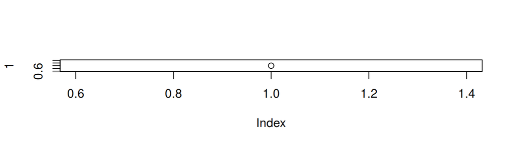

ここからキャプションです．

fig.capは，チャンクの評価終了後に評価されます． 従って，図を作るチャンクの中に，fig.capに与える文字列を持つ変数を作ることができます．

また，長いキャプションは，ほどほどの長さで改行したいですね． チャンクオプションは改行を許しませんが，チャンク内なら自在です． paste() を使うと，

```
paste(
"AAA",
"BBB",
"CCC"
)
```

といった具合にコンマとダブルクオーテーションマークを多様する必要があります． glueパッケージも使うと楽でいいですね． キャプションとして必要かどうかはさておいて，マークダウン記法が許されます． 空白4つでコードブロック化もできます．

改行するために空白行を挟むと，pandocの仕様のためか，段落と見做されてしまう点は注意が必要そうですね．

バックスラッシュ2つでバックスラッシュをエスケープしても強制改行にはならないみたいですな．

一方，スペース二つを  
末尾に置く場合は改行できています．

ここまでキャプションです．

# 以下ソース

`` ```{r fig, fig.height = 1, fig.cap = cap} ``

```r
cap <- glue::glue(
  '
  ここからキャプションです．

  　fig.capは，チャンクの評価終了後に評価されます．
  従って，図を作るチャンクの中に，fig.capに与える文字列を持つ変数を作ることができます．

  　また，長いキャプションは，ほどほどの長さで改行したいですね．
  チャンクオプションは改行を許しませんが，チャンク内なら自在です．
  paste() を使うと，

      paste(
      "AAA",
      "BBB",
      "CCC"
      )

  といった具合にコンマとダブルクオーテーションマークを多様する必要があります．
  glueパッケージも使うと楽でいいですね．
  キャプションとして必要かどうかはさておいて，マークダウン記法が許されます．
  空白4つでコードブロック化もできます．

  改行するために空白行を挟むと，pandocの仕様のためか，段落と見做されてしまう点は注意が必要そうですね．

  バックスラッシュ2つ\\
  でバックスラッシュをエスケープしても強制改行にはならないみたいですな．

  一方，スペース二つを
  末尾に置く場合は改行できています．

  ここまでキャプションです．
  '
)

plot(x = 1)
```

`` ``` ``